# Week12

Vivian Kong

4/24/2018

> Question 1

```r
who <- read.csv("https://raw.githubusercontent.com/xkong100/DATA_605/master/week12/who.csv")
head(who)
```

```
##               Country LifeExp InfantSurvival Under5Survival  TBFree
## 1         Afghanistan      42          0.835          0.743 0.99769
## 2             Albania      71          0.985          0.983 0.99974
## 3             Algeria      71          0.967          0.962 0.99944
## 4             Andorra      82          0.997          0.996 0.99983
## 5              Angola      41          0.846          0.740 0.99656
## 6 Antigua and Barbuda      73          0.990          0.989 0.99991
##        PropMD      PropRN PersExp GovtExp TotExp
## 1 0.000228841 0.000572294      20      92    112
## 2 0.001143127 0.004614439     169    3128   3297
## 3 0.001060478 0.002091362     108    5184   5292
## 4 0.003297297 0.003500000    2589  169725 172314
## 5 0.000070400 0.001146162      36    1620   1656
## 6 0.000142857 0.002773810     503   12543  13046
```

```r
summary(who)
```

```
##                 Country       LifeExp      InfantSurvival
##  Afghanistan        :  1   Min.   :40.00   Min.   :0.8350
##  Albania            :  1   1st Qu.:61.25   1st Qu.:0.9433
##  Algeria            :  1   Median :70.00   Median :0.9785
##  Andorra            :  1   Mean   :67.38   Mean   :0.9624
##  Angola             :  1   3rd Qu.:75.00   3rd Qu.:0.9910
##  Antigua and Barbuda:  1   Max.   :83.00   Max.   :0.9980
##  (Other)            :184
##  Under5Survival       TBFree           PropMD              PropRN
##  Min.   :0.7310   Min.   :0.9870   Min.   :0.0000196   Min.   :0.0000883
##  1st Qu.:0.9253   1st Qu.:0.9969   1st Qu.:0.0002444   1st Qu.:0.0008455
##  Median :0.9745   Median :0.9992   Median :0.0010474   Median :0.0027584
##  Mean   :0.9459   Mean   :0.9980   Mean   :0.0017954   Mean   :0.0041336
##  3rd Qu.:0.9900   3rd Qu.:0.9998   3rd Qu.:0.0024584   3rd Qu.:0.0057164
##  Max.   :0.9970   Max.   :1.0000   Max.   :0.0351290   Max.   :0.0708387
##
##     PersExp           GovtExp             TotExp
##  Min.   :   3.00   Min.   :    10.0   Min.   :    13
##  1st Qu.:  36.25   1st Qu.:   559.5   1st Qu.:   584
##  Median : 199.50   Median :  5385.0   Median :  5541
##  Mean   : 742.00   Mean   : 40953.5   Mean   : 41696
##  3rd Qu.: 515.25   3rd Qu.: 25680.2   3rd Qu.: 26331
##  Max.   :6350.00   Max.   :476420.0   Max.   :482750
##
```

```r
who.lm <- lm(who$LifeExp~who$TotExp)
who.lm
```

```
##
## Call:
## lm(formula = who$LifeExp ~ who$TotExp)
##
## Coefficients:
## (Intercept)   who$TotExp
##   6.475e+01    6.297e-05
```

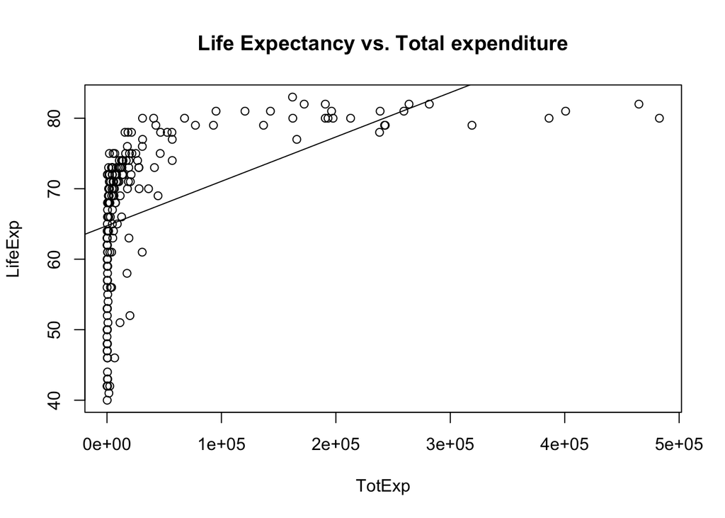

```r
plot(who$TotExp,who$LifeExp, main="Life Expectancy vs. Total expenditure", xlab="TotExp", ylab="LifeExp")
abline(who.lm)
```

```r
summary(who.lm)
```

```
##
## Call:
## lm(formula = who$LifeExp ~ who$TotExp)
##
## Residuals:
##     Min      1Q  Median      3Q     Max
## -24.764  -4.778   3.154   7.116  13.292
##
## Coefficients:
##              Estimate Std. Error t value Pr(>|t|)
## (Intercept) 6.475e+01  7.535e-01  85.933  < 2e-16 ***
## who$TotExp  6.297e-05  7.795e-06   8.079 7.71e-14 ***
## ---
## Signif. codes:  0 '***' 0.001 '**' 0.01 '*' 0.05 '.' 0.1 ' ' 1
##
## Residual standard error: 9.371 on 188 degrees of freedom
## Multiple R-squared:  0.2577, Adjusted R-squared:  0.2537
## F-statistic: 65.26 on 1 and 188 DF,  p-value: 7.714e-14
```

- F statistics is not particularly useful here since F statistics compares to a model has one fewer parameter since our model is single-variable linear model, F statistics can’t say a lot about our linear model.
- For R^2, we have 2 values, multiple R-squared is 0.2577 and adjusted R-square is 0.2537. Since the adjusted R-square modified to take into account the number of predictors well in the model, we only have 1 predictor in this linear model, it does not help use too much for this model as well. For the multiple R-square is 0.2577 which means that this linear model explains 25.77% of the data’s variation. This number is relatively low and we need to improve our model.
- For standard error, good model needs the standard error at least 5-10 times less than the corresponding coefficient.
  - In our case, it is the total expenditure. the coefficient is 6.297e^-5 and standard error of the coefficient is 7.795e^-6, the standard error is about 8 times less than the coefficient of total expenditure. It is a good sign to indicate it is a reasonable linear model because the larger ratio is relatively little bariablity in the slope estimate.
  - For intercept standard error, it is about 85 times less than the coefficient of the intercept. which is also a pretty good sign for our model.
  - For residual standard deviation, it is a measure of the total variation in the residual values. For our residual graph, is not quite line up to 0, it means that the linear model needs to be improved.
- P-value, 7.714e-14. p-value measures the probablity of corresponding coefficient is not relevant in the model. when p-value is small enough such as p-value < 0.05, which indicates that the linear model we have is a good model. In our case, p-value is significantly small.

In conclusion, Our model between total expenditure and Life expectance for the country should be correlated but we may need to throw more variables into our model to make it better.

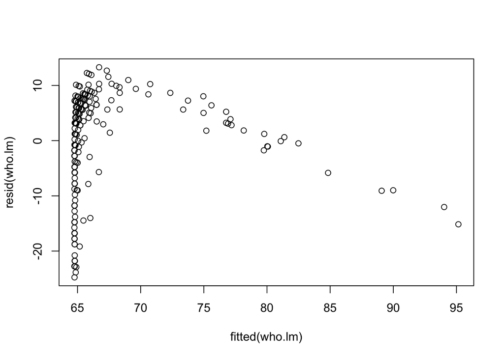

```r
plot(fitted(who.lm), resid(who.lm))
```

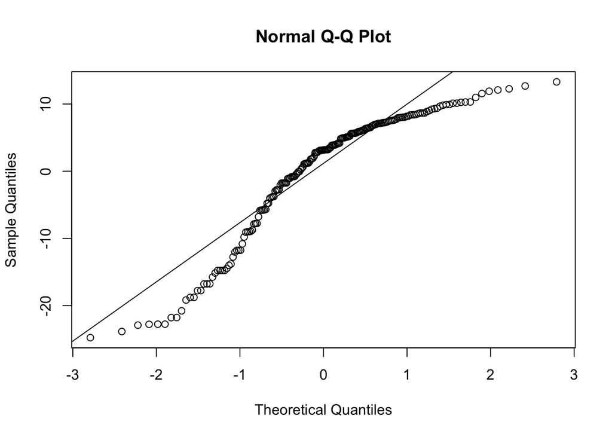

```r
qqnorm(resid(who.lm))
qqline(resid(who.lm))
```

> Question 2

```r
nLifeExp <- who$LifeExp^4.6
head(nLifeExp)
```

```
## [1]  29305338 327935478 327935478 636126841  26230450 372636298
```

```r
nTotExp <- who$TotExp^0.06
head(nTotExp)
```

```
## [1] 1.327251 1.625875 1.672697 2.061481 1.560068 1.765748
```

```r
nwho.lm <- lm(nLifeExp~nTotExp)
nwho.lm
```

```
##
## Call:
## lm(formula = nLifeExp ~ nTotExp)
##
## Coefficients:
## (Intercept)      nTotExp
##  -736527909    620060216
```

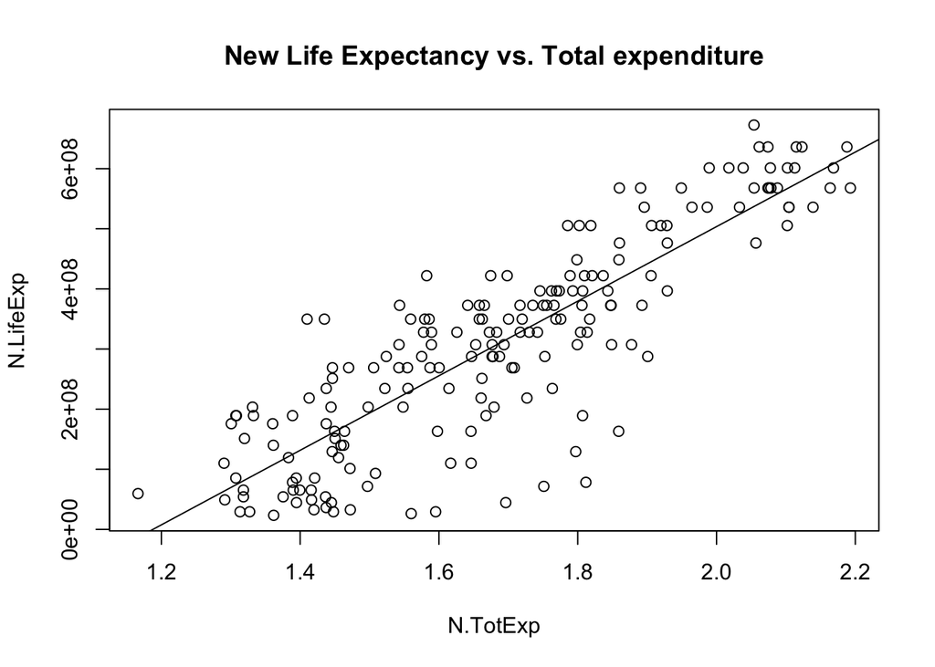

```r
plot(nTotExp,nLifeExp, main="New Life Expectancy vs. Total expenditure", xlab="N.TotExp", ylab="N.LifeExp")
abline(nwho.lm)
```